# All_homework

By 20068

2020-12-19

# HW-2020-09-22

## Question 1 : Use knitr to produce an example which should contain texts and at least one figure.

## Answer :

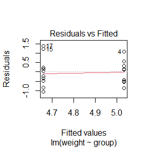

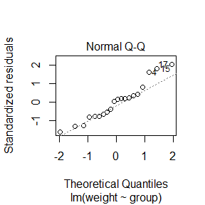

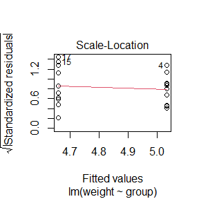

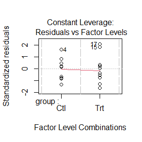

```r
ctl <- c(4.17,5.58,5.18,6.11,4.50,4.61,5.17,4.53,5.33,5.14)
trt <- c(4.81,4.17,4.41,3.59,5.87,3.83,6.03,4.89,4.32,4.69)
group <- gl(2, 10, 20, labels = c("Ctl","Trt"))
weight <- c(ctl, trt)
lm.D9 <- lm(weight ~ group)
plot(lm.D9)
```

## Question 2 : Use knitr to produce an example which should contains texts and at least one table.

## Answer :

```r
knitr::kable (head(iris))
```

| Sepal.Length | Sepal.Width | Petal.Length | Petal.Width | Species |
| --- | --- | --- | --- | --- |
| 5.1 | 3.5 | 1.4 | 0.2 | setosa |
| 4.9 | 3.0 | 1.4 | 0.2 | setosa |
| 4.7 | 3.2 | 1.3 | 0.2 | setosa |
| 4.6 | 3.1 | 1.5 | 0.2 | setosa |
| 5.0 | 3.6 | 1.4 | 0.2 | setosa |
| 5.4 | 3.9 | 1.7 | 0.4 | setosa |

## Question 3 : Use knitr to produce an example which should contain at least a couple of LaTeX formulas.

## Answer :

- A simple formula

  $$A_1+A_2=0$$
- A complicated formula

  $$A_{i,j}=\frac{1}{(k_j-i)!} \frac{d^{k_j-i}}{ds^{k_j-i}} \{ \frac{T_{m-1}(s)}{\Pi_{l=1,l \neq j}^n (s-R_l)^{k_l}} \} |_{s=R_j}$$

# HW-2020-09-29

## Question 1 :

The Pareto(a,b) distribution has cdf
$$F(x)=1-(\frac{b}{x})^{a}, \quad \quad x \geq b >0,a>0$$
Derive the probability inverse transformation $F^{-1}(U)$ and use the inverse transform method to simulate a random sample from the Pareto(2, 2) distribution. Graph the density histogram of the sample with the Pareto(2, 2) density superimposed for comparison.

## Answer :

$U=F(x) \sim U[0,1]$,then $U=F(x)=1-(\frac{b}{x})^a,x \geq b>0,a>0$.

According $U=1-(\frac{b}{x})^a$,then we can deduce $x=\frac{b}{(1-U)^{\frac{1}{a}}}$ and calculate the density function $f(x)=(F(x))'=\frac{ab^a }{x^{a+1}},x \geq b$.

Now, we use the inverse transform method to simulate a random sample from the Pareto(2, 2) distribution and Graph the density histogram of the sample with the Pareto(2, 2) density superimposed for comparison.

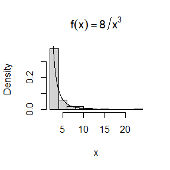

```r
set.seed(20)
n=100
u=runif(n)
x=2/sqrt(1-u)  #F(x)=1-(2/x)^2 ,x>=b>0,a>0
hist(x,prob=TRUE,main = expression(f(x)==8/x^3))
y=seq(2,max(x),0.01)
lines(y,8*(1/(y^3)))
```

## Question 2 :

The rescaled Epanechnikov kernel [85] is a symmetric density function
$$f_e(x)=\frac{3}{4}(1-x^2), \quad \quad |x| \leq 1$$
Devroye and Gyorfi [71, p. 236] give the following algorithm for simulation from this distribution. Generate iid $U_1,U_2,U_3 \sim Uniform(-1,1)$. If $|U_3| \geq |U_2|$ and$|U_3| \geq |U_1|$, deliver $U_2$ ; otherwise deliver$U_3$ . Write a function to generate random variates from $f_e$ , and construct the histogram density estimate of a large simulated random sample.

## Answer :

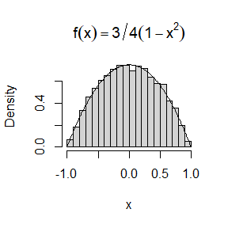

```r
n=10000
u1=2*runif(n)-1;u2=2*runif(n)-1;u3=2*runif(n)-1;
x=vector();
for (i in 1:n){
  if (abs(u3[i])>abs(u2[i]) && abs(u3[i])>abs(u1[i])){
    x[i]=u2[i]
    }else
    x[i]=u3[i]
}
hist(x,prob=TRUE,main = expression(f(x)==3/4*(1-x^2)))
y=seq(-1,1,0.01)
lines(y,3/4*(1-y^2))
```

## Question 3 :

Prove that the algorithm given in question 2 generates variates from the density $f_e$.

## Answer :

第一步：先求解$|f_e|$的密度函数，令$X=|U_1|,Y=|U_2|,Z=|U_3|$,则由上题算法知：
$$W=\begin{cases}
Y \quad & Z \geq max\{X,Y\} \\
Z \quad & Z <max\{ X,Y\}
\end{cases}$$

a.求解$W$的分布函数：
$$\begin{aligned}
P(W \leq w)&=P(Y\leq w,Z\geq max\{X,Y\})+P(Z\leq w,Z< max\{X,Y\}) \\
&=\int_0^w \int_0^1 \int_{max\{X,Y\}}^1 1 dzdxdy+\int_0^1 \int_0^1 \int_0^{min\{w,max\{X,Y\}\}} 1 dzdxdy \\
&= I+II
\end{aligned}$$

b.计算$I,II$
$$I=\begin{aligned}
\int_0^w \int_0^1 \int_{max\{X,Y\}}^1 1 dzdxdy &=\int_0^w \int_0^1 1-max\{X,Y\} dx dy =-\frac{1}{6}w^3+\frac{1}{2}w
\end{aligned}$$
对式子$II$分类讨论，计算如下：
$$\begin{aligned}
II&= \int_w^1 \int_x^1 w dydx +\int_w^1 \int_w^x w dydx + \int_w^1 \int_0^w w dy dx + \int_0^w \int_w^1 w dydx + \int_0^w \int_x^w y dydx + \int_0^w \int_0^x dydx \\
&=w-\frac{1}{3}w^3
\end{aligned}$$
因此$P(W \leq w)=\frac{w}{2}-\frac{w^3}{6}+w-\frac{w^3}{3}=\frac{3w}{2}-\frac{w^3}{2}$

第二步：计算密度函数：

分布函数$F(w)=\frac{3w}{2}-\frac{w^3}{2}$，密度函数$f(w)=\frac{3}{2}-\frac{3w^2}{2}$。由$f_e$为对称函数，将其密度函数除2可得：$f_e(w)=\frac{3}{4}(1-w^2),w \in [-1,1]$

Use Kolmogorov-Smirnov test to test whether variables follow F distribution.

```r
F=-0.25*y^3+0.75*y+0.5
ks.test(x,F)
```

```
##
##  Two-sample Kolmogorov-Smirnov test
##
## data:  x and F
## D = 0.5034, p-value < 2.2e-16
## alternative hypothesis: two-sided
```

## Question 4 :

It can be shown that the mixture in Exercise 3.12 has a Pareto distribution with cdf
$$F(y)=1-(\frac{\beta}{\beta+y})^r,\quad y \geq 0$$
(This is an alternative parameterization of the Pareto cdf given in question 1.) Generate 1000 random observations from the mixture with $r=4$ and $\beta=2$. Compare the empirical and theoretical (Pareto) distributions by graph- ing the density histogram of the sample and superimposing the Pareto density curve.

## Answer :

According $r=4,\beta=2,F(y)=1-(\frac{\beta}{\beta+y})^r=1-(\frac{2}{2+y})^4=U \sim U[0,1]$,then deduce $y=\frac{2}{(1-u)^{1/4}}-2$ and $f(y)=(F(y))'=64(2+y)^{-5}$

Now, we use the inverse transform method to simulate a random sample from the $F(y)$ distribution and Graph the density histogram of the sample with the $F(y)$ density superimposed for comparison.

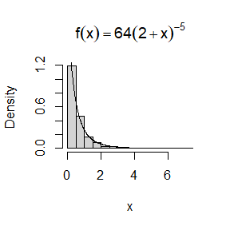

```r
set.seed(70)
n=1000
u=runif(n)
x=2/((1-u)^(1/4))-2  #F(x)=1-(2/x)^2 ,x>=b>0,a>0
hist(x,prob=TRUE,main = expression(f(x)==64*(2+x)^{-5}))
y=seq(0,max(x),0.01)
lines(y,64*(2+y)^{-5})
```

# HW-2020-10-13

## Exercises 5.1

Compute a Monte Carlo estimate of $\int_0^{\frac{\pi}{3}} sin (t) dt$ and compare your estimate with the exact value of the integral.

## Solve.

$\int_0^{\frac{\pi}{3}} sin(t)dt=\frac{\pi}{3}\int_0^{\frac{\pi}{3}} sin(t)\frac{3}{\pi}dt=\frac{\pi}{3} E[sin(u)],u \sim U[0,1]$

$\int_0^{\frac{\pi}{3}} sin(t)dt=-cos(t)|_0^{\frac{\pi}{3}}=1/2$

```r
set.seed(66)
number=1000000
exact_value=1/2
u=runif(number,min = 0,max = pi/3)
MC_value=pi/3*mean(sin(u))
print(c(MC_value,exact_value,abs(MC_value-exact_value)))
```

```
## [1] 5.000377e-01 5.000000e-01 3.766845e-05
```

Therefore, the estimated value is 5.000377e-01 and the theoretical value is 0.5

## Exercises 5.7

Refer to Exercise 5.6. Use a Monte Carlo simulation to estimate $\theta$ by the antithetic variate approach and by the simple Monte Carlo method. Compute an empirical estimate of the percent reduction in variance using the antithetic variate. Compare the result with the theoretical value from Exercise 5.6.

## Solve.

$\theta=\int_0^1 e^x dx=e-1$

$\hat{\theta}_1=\frac{1}{2m} \sum_{i=1}^m [e^{u_i}+e^{1-{u_i}}],u_i \sim U[0,1]$

$\hat{\theta}_2=E(e^U)=\frac{1}{m} \sum_{i=1}^m e^{u_i},u_i \sim U[0,1]$

$var(e^U)=E[e^{2U}]-(E[e^U])^2=0.2420$

$cov(e^U,e^{1-U})=E[e^Ue^{1-U}]-E[e^U]E[e^{1-U}]=e-(e-1)^2=-0.2342$

$var(\frac{e^{U_1}+e^{U_2}}{2})=var(e^U)/2=0.1210$

$Var(\frac{e^U+e^{1-U}}{2})=Var(\frac{e^U}{2})+Var(\frac{e^{1-U}}{2})+2cov(\frac{e^U}{2},\frac{e^{1-U}}{2})=\frac{e^2-1+2e-4(e-1)^2}{4}=0.0039$

The theoretical value of the percentage reduction of variance should be $\frac{0.1210-0.0039}{0.1210} \approx 0.967$

```r
set.seed(66)
number=1000
exact_value=exp(1)-1
n=1000
MC_value1=vector()
MC_value2=vector()
for (i in 1:n){
  u1=runif(number)
  u2=runif(number)
  MC_value1[i]=1/2*mean(exp(u1)+exp(1-u1))
  MC_value2[i]=mean((exp(u1)+exp(u2))/2)
}
sd1=sd(MC_value1)
sd2=sd(MC_value2)
print(c(exact_value,mean(MC_value1),mean(MC_value2),sd1,sd2))
```

```
## [1] 1.718281828 1.718383530 1.718690689 0.002005904 0.010725576
```

Therefore, the empirical estimate of the percent reduction in variance using the antithetic variate is

```r
print(1-var(MC_value1)/var(MC_value2))
```

```
## [1] 0.9650233
```

So the empirical estimate of the percentage reduction in variance is close to the theoretical value.

## Exercises 5.11

If $\hat{\theta_1}$ and $\hat{\theta_2}$ are unbiased estimators of $\theta$, and $\theta_1$ and $\theta_2$ are antithetic, we derived that$c^*=1/2$ is the optimal constant that minimizes the variance of $\hat{\theta}_c=c \hat{\theta}_1+(1-c)\hat{\theta}_2$ . Derive $c^*$ for the general case. That is, if $\hat{\theta}_1$and $\hat{\theta}_2$ are any two unbiased estimators of θ, ﬁnd the value c ∗ that minimizes the variance of the estimator $\hat{\theta}_c=c \hat{\theta}_1+(1-c)\hat{\theta}_2$in equation (5.11). ($c^*$ will be a function of the variances and the covariance of the estimators.)

## Prove:

Because of $\hat{\theta}_c=c \hat{\theta}_1+(1-c)\hat{\theta}_2$,We can derive that:
$$\begin{aligned}
var(\hat{\theta}_c)&=var(c \hat{\theta}_1+(1-c)\hat{\theta}_2)\\
&=c^2 var(\hat{\theta}_1)+(1-c)^2 var(\hat{\theta}_2)+2c(1-c)cov(\hat{\theta}_1,\hat{\theta}_2) \\
&=c^2[var(\hat{\theta}_1)+var(\hat{\theta}_2)-2cov(\hat{\theta}_1,\hat{\theta}_2)]+c[2cov(\hat{\theta}_1,\hat{\theta}_2)-2var(\hat{\theta}_2)]+var(\hat{\theta}_2) \\
&=c^2 var(\hat{\theta}_1-\hat{\theta}_2)+c[2cov(\hat{\theta}_1,\hat{\theta}_2)-2var(\hat{\theta}_2)]+var(\hat{\theta}_2)
\end{aligned}$$
Therefore, according to the above derivation,when
$$c^*=-\frac{b}{2a}=-\frac{cov(\hat{\theta}_1,\hat{\theta}_2)-var(\hat{\theta}_2)}{ var(\hat{\theta}_1-\hat{\theta}_2)}$$
The variance can be minimized.

If $\hat{\theta_1}$ and $\hat{\theta_2}$ are unbiased estimators of $\theta$, and $\theta_1$ and $\theta_2$ are antithetic,then we know that $\hat{\theta_1}+\hat{\theta_2}=1$.
$$\begin{aligned}
cov(\hat{\theta_1},\hat{\theta_2})&=cov(\hat{\theta_1},1-\hat{\theta_1})=-var(\hat{\theta_1}) \\
c^*&=\frac{cov(\hat{\theta}_1,\hat{\theta}_2)-var(\hat{\theta}_2)}{ var(\hat{\theta}_1-\hat{\theta}_2)}=\frac{1}{2}
\end{aligned}$$

# HW-2020-10-20

## Exercises 5.13

Find two importance functions $f_1$and$f_2$that are supported on $(0,\infty)$ and are ‘close’ to $g(x)=\frac{x^2}{\sqrt{2\pi}} e^{-\frac{x^2}{2}}, x>1$,Which of your two importance functions should produce the smaller variance in estimating$\int_{1}^{\infty} \frac{x^2}{\sqrt{2\pi}} e^{-\frac{x^2}{2}} dx$ by importance sampling? Explain.

## Solve.

Suppose $f_1(x)=xe^{\frac{1-x^2}{2}}$ and $f_2(x)=e^{-x}$

use the inverse transformation method for the $f_1(x)$ function:

$F_1(x)=\int_1^x f_1(x)dx=1-e^{\frac{1-x^2}{2}}=U \sim U[0,1] \Rightarrow x=\sqrt{1-2log(1-u)}$

```r
set.seed(0)
m=10000
theta.hat=var.hat=numeric(2)
g=function(x){
  (x^2*exp(-x^2/2)/sqrt(2*pi))*(x>1)
}

u=runif(m)                    ##inverse transform method
x=sqrt(1-2*log(1-u))
fg1=g(x)/(exp(1/2-x^2/2)*x)
theta.hat[1]=mean(fg1)
var.hat[1]=var(fg1)

x=rexp(m,1)
fg2=g(x)/(exp(-x))
theta.hat[2]=mean(fg2)
var.hat[2]=var(fg2)

print(rbind(theta.hat,var.hat))
```

```
##                 [,1]      [,2]
## theta.hat 0.40129699 0.4016908
## var.hat   0.01541051 0.3419579
```

By using importance functions$f_1(x),f_2(x)$, We get the variance of the estimated value as 0.01541051 and 0.3419579.So the function $f_1(x)$produces the smaller variance.

## Exercises 5.15

Obtain the stratiﬁed importance sampling estimate in Example 5.13 and compare it with the result of Example 5.10.

## Solve.

$g(x)=\frac{e^{-x}}{1+x^2},x \in (0,1)$

$f(x)=\frac{e^{-x}}{e^{-\frac{i-1}{5}}-e^{-\frac{i}{5}}}, x \in (\frac{i-1}{5},\frac{i}{5})$

$\int_0^1 g(x)dx=\sum_{i=1}^5 \int_{\frac{i-1}{5}}^{\frac{i}{5}} g(x)dx =\sum_{i=1}^5 \int_{\frac{i-1}{5}}^{\frac{i}{5}} \frac{g(x)}{f(x)} f(x)dx =\sum_{i=1}^5 E(\frac{g(x)}{f(x)}) \quad x \in (\frac{i-1}{5},\frac{i}{5})$

```r
set.seed(0)
m=100;k=5;r=m/k;n=50;t2=numeric(k)
estimates=matrix(0,n,2)

g=function(x){exp(-x)/(1+x^2)*(x>0)*(x<1)}
f=function(x){exp(-x)/(exp((1-j)/5)-exp(-j/5))}

for (i in 1:n){
  estimates[i,1]=mean(g(runif(m)))
  for ( j in 1:k){
    u=runif(m/k)
    x=-log(exp(-(j-1)/5)-u*(exp((1-j)/5)-exp(-j/5)))
    t2[j]=mean(g(x)/f(x))
  }
  estimates[i,2]=sum(t2)
}
apply(estimates,2,mean)
```

```
## [1] 0.5246927 0.5248410
```

```r
apply(estimates,2,var)
```

```
## [1] 6.392113e-04 3.299438e-06
```

This represents a more than 99.4% reduction in variance.

## Exercises 6.4

Suppose that $X_1,\dots,X_n$are a random sample from a from a lognormal distribution with unknown parameters. Construct a 95% conﬁdence interval for the parameter $u$ . Use a Monte Carlo method to obtain an empirical estimate of the conﬁdence level.

## Solve.

Suppose that $X_1,\dots,X_n \overset{iid}{\sim} LN(u,\sigma^2)$, then $log(X_1), \dots,log(X_n) \overset{iid}{\sim} N(u,\sigma^2)$.Because the parameter $\sigma$ is unknown, construct statistics:
$$T=\frac{\sqrt{n}(\bar{Y}-u)}{S} \sim t(n-1)$$
and $Y_i=log(X_i),S=\sqrt{S^2}$,$S^2$ is the variance of the sample $(Y_1,\dots,Y_n)$. Therefore, the $1-\alpha$ confidence interval of the parameter $u$ is
$$[\bar{Y}-\frac{S}{\sqrt{n}} t_{\frac{\alpha}{2}}(n-1),\bar{Y}+\frac{S}{\sqrt{n}} t_{\frac{\alpha}{2}}(n-1)]$$
take $\alpha=0.05$, then we can get confidence interval of the parameter $u$. Draw 20 samples from the population $LN(0,1)$ each time, repeat 100000 times, and perform Monte Carlo simulation to get the confidence level estimate as follows:

```r
set.seed(0)
n=20
alpha=0.05
u=0;sigma=1;
number=100000
Icl=vector();ucl=vector();

for (i in 1:number){
  x=rnorm(n,mean = u,sd=sigma)
  s=sqrt(var(x)*n/(n-1))
  ucl[i]=mean(x)+s/sqrt(n)*qt(1-alpha/2,n-1)
  Icl[i]=mean(x)-s/sqrt(n)*qt(1-alpha/2,n-1)
}
Icl1=mean(Icl);ucl1=mean(ucl)

a=0;
for (i in 1:number){
  if (Icl[i]<0&&ucl[i]>0)a=a+1
  else a=a
}
p=a/number

print(c(Icl1,ucl1))
```

```
## [1] -0.4740950  0.4736912
```

```r
print(p)
```

```
## [1] 0.95506
```

The result is that 95506 intervals satisfied (Icl<0<ucl), so the empirical confidence level is 95.506% in this experiment. The result will vary but should be close to the theoretical value, 95%.

## Exercises 6.5

Suppose a 95% symmetric t-interval is applied to estimate a mean, but the sample data are non-normal. Then the probability that the conﬁdence interval covers the mean is not necessarily equal to 0.95. Use a Monte Carlo experiment to estimate the coverage probability of the t-interval for random samples of $\chi^2(2)$ data with sample size n = 20. Compare your t-interval results with the simulation results in Example 6.4. (The t-interval should be more robust to departures from normality than the interval for variance.)

## Solve.

```r
set.seed(0)
n=20;alpha=0.05;number=1000;
Icl=vector();ucl=vector();

for (i in 1:number){
  x=rchisq(n,df=2)
  s=sqrt(var(x)*n/(n-1))
  ucl[i]=mean(x)+s/sqrt(n)*qt(1-alpha/2,n-1)
  Icl[i]=mean(x)-s/sqrt(n)*qt(1-alpha/2,n-1)
}
Icl1=mean(Icl);ucl1=mean(ucl)

a=0;
for (i in 1:number){
  if (Icl[i]<2&&ucl[i]>2)a=a+1
  else a=a
}
p=a/number

print(c(Icl1,ucl1))
```

```
## [1] 1.086875 2.915805
```

```r
print(p)
```

```
## [1] 0.931
```

# HW-2020-10-27

## Exercises 6.7

Estimate the power of the skewness test of normality against symmetric $Beta(\alpha, \alpha)$ distributions and comment on the results. Are the results different for heavy-tailed symmetric alternatives such as $t(v)$?

## Solve.

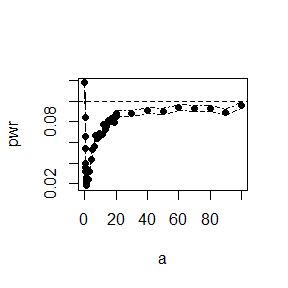

```r
set.seed(12345)

sk = function(x) {
  xbar = mean(x)
  m3 = mean((x - xbar)^3)
  m2 = mean((x - xbar)^2)
  return( m3 / m2^1.5 )
}

# beta(a,a)
pwr_beta = function(a){
 alpha = 0.1
 n = 20
 m = 1e4
 N = length(a)
 pwr = numeric(N)
 cv = qnorm(1-alpha/2, 0, sqrt(6*(n-2) / ((n+1)*(n+3))))

 for (j in 1:N) {
  sktests = numeric(m)
  for (i in 1:m) {
   x = rbeta(n, a[j], a[j])
   sktests[i] = as.integer(abs(sk(x))>= cv)
  }
  pwr[j] = mean(sktests)
 }
 se = sqrt(pwr * (1-pwr) / m)
 return(list(pwr = pwr,se = se))
}

 a = c(seq(0,1,0.1),seq(1,20,1),seq(20,100,10))
 pwr = pwr_beta(a)$pwr
 # plot the power
 se = pwr_beta(a)$se
 plot(a, pwr, type = "b", xlab = "a", ylab = "pwr", pch=16)
 abline(h = 0.1, lty = 2)
 lines(a, pwr+se, lty = 4)
 lines(a, pwr-se, lty = 4)
```

## Exercises 6.8

Refer to Example 6.16. Repeat the simulation, but also compute the F test . of equal variance, at signiﬁcance level $\hat{\alpha} \overset{.}{=} 0.055$. Compare the power of the Count Five test and F test for small, medium, and large sample sizes. (Recall that the F test is not applicable for non-normal distributions.)

## Solve.

```r
set.seed(0)
m=1000;alpha=0.055;
sigma1=1;sigma2=1.5
number1=numeric(m);number2=numeric(m)
pwr1=numeric(3);pwr2=numeric(3)

count5test=function(x,y){
  x=x-mean(x)
  y=y-mean(y)
  outx=sum(x>max(y))+sum(x<min(y))
  outy=sum(y>max(x))+sum(y<min(x))
  return(as.integer(max(c(outx,outy))>=5))
}

a=c(10,100,2000)
for (i in 1:3){
  n1=a[i];n2=a[i];
  for (j in 1:m){
    x=rnorm(n1,0,sqrt(sigma1))
    y=rnorm(n2,0,sqrt(sigma2))
    s1=var(x)
    s2=var(y)
    F_value=s1/s2
    number1[j]=count5test(x,y)
    number2[j]=as.integer(F_value>qf(1-alpha/2,n1-1,n2-1)||F_value<qf(alpha/2,n1-1,n2-1))
  }
  pwr1[i]=mean(number1)
  pwr2[i]=mean(number2)
}
print(cbind(pwr1,pwr2))
```

```
##       pwr1  pwr2
## [1,] 0.102 0.083
## [2,] 0.455 0.542
## [3,] 0.912 1.000
```

## Exercises 6.C

Repeat Examples 6.8 and 6.10 for Mardia’s multivariate skewness test. Mardia [187] proposed tests of multivariate normality based on multivariate generalizations of skewness and kurtosis. If X and Y are iid, the multivariate population skewness β 1,d is deﬁned by Mardia as
$$\beta_{1,d}=E[(X-u)^T \Sigma^{-1}(Y-u)]^3$$

Under normality, $\beta_{1,d}= 0$. The multivariate skewness statistic is
$$b_{1,d}=\frac{1}{n^2} \sum_{i,j=1}^n ((X_i-\bar{X})^T \hat{\Sigma}^{-1}(Y_j-\bar{X}))^3$$

where $\hat{\Sigma}$ is the maximum likelihood estimator of covariance. Large values of b 1,d are signiﬁcant. The asymptotic distribution of $nb_{1,d}/6$ is chisquared with $d(d + 1)(d + 2)/6$ degrees of freedom.

## Solve.

```r
library(MASS)
Mardia<-function(mydata){
  n=nrow(mydata)
  c=ncol(mydata)
  central<-mydata
  for(i in 1:c){
    central[,i]<-mydata[,i]-mean(mydata[,i])
  }
  sigmah<-t(central)%*%central/n
  a<-central%*%solve(sigmah)%*%t(central)
  b<-sum(colSums(a^{3}))/(n*n)
  test<-n*b/6
  chi<-qchisq(0.95,c*(c+1)*(c+2)/6)
  as.integer(test>chi)
}

set.seed(1234)
mu <- c(0,0,0)
sigma <- matrix(c(1,0,0,0,1,0,0,0,1),nrow=3,ncol=3)
m=1000
n<-c(10, 20, 30, 50, 100, 500)
#m: number of replicates; n: sample size
a=numeric(length(n))
for(i in 1:length(n)){
  a[i]=mean(replicate(m, expr={
    mydata <- mvrnorm(n[i],mu,sigma)
    Mardia(mydata)
  }))
}
print(a)
```

```
## [1] 0.001 0.017 0.036 0.049 0.046 0.054
```

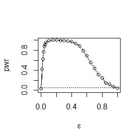

```r
library(MASS)
set.seed(7912)
set.seed(7912)
mu1 <- mu2 <- c(0,0,0)
sigma1 <- matrix(c(1,0,0,0,1,0,0,0,1),nrow=3,ncol=3)
sigma2 <- matrix(c(100,0,0,0,100,0,0,0,100),nrow=3,ncol=3)
sigma=list(sigma1,sigma2)
m=1000
n=50
#m: number of replicates; n: sample size
epsilon <- c(seq(0, .06, .01), seq(.1, 1, .05))
N <- length(epsilon)
pwr <- numeric(N)
for (j in 1:N) { #for each epsilon
  e <- epsilon[j]
  sktests <- numeric(m)
  for (i in 1:m) { #for each replicate
    index=sample(c(1, 2), replace = TRUE, size = n, prob = c(1-e, e))
    mydata<-matrix(0,nrow=n,ncol=3)
    for(t in 1:n){
      if(index[t]==1) mydata[t,]=mvrnorm(1,mu1,sigma1)
      else mydata[t,]=mvrnorm(1,mu2,sigma2)
    }
    sktests[i] <- Mardia(mydata)
  }
  pwr[j] <- mean(sktests)
}
plot(epsilon, pwr, type = "b",
     xlab = bquote(epsilon), ylim = c(0,1))
abline(h = .05, lty = 3)
se <- sqrt(pwr * (1-pwr) / m) #add standard errors
lines(epsilon, pwr+se, lty = 3)
lines(epsilon, pwr-se, lty = 3)
```

## Discussion

If we obtain the powers for two methods under a particular simulation setting with 10,000 experiments: say, 0.651 for one method and 0.676 for another method. Can we say the powers are different at 0.05 level?  
(1)What is the corresponding hypothesis test problem?  
(2)What test should we use? Z-test, two-sample t-test, paired-t test or McNemar test?  
(3)What information is needed to test your hypothesis?

## Solve

### (1)

Null hypothesis $H_0:power1=power2$ . alternative hypothesis $H_1:power1 \neq power2$

### (2)

(a)Z-test: Assume $x_i=power1(i),y_i=power2(i),z_i=x_i-y_i$,Test whether the mean of $z_i$ is 0. two-sample t-test.

(b)The sample data of the two-sample t-test is required to come from two independent populations, which is not related. But both power1 and power2 are generated in the same population, so the two-sample t test cannot be used.

(c)The paired-sample t-test is a special case of the one-sample t-test. There are many cases of paired t-test: two subjects who are paired receive two different treatments respectively; the same subject receives two different treatments; the results of the same subject before and after treatment are compared (ie self-pairing).

(d)The McNemar test uses two methods to test the same sample, and compares the differences between the two methods, using the paired chi-square test.

### (3)

A large enough sample, power1 and power2 calculated by two methods

# HW-2020-11-03

## Exercises 7.1

Compute a jackknife estimate of the bias and the standard error of the correlation statistic in Example 7.2.

## Solve.

```r
data(law,package = "bootstrap")
n=nrow(law)
x=law$LSAT
y=law$GPA

theta.hat=cor(x,y)
theta.jack=numeric(n)

for(i in 1:n){
  theta.jack[i]=cor(x[-i],y[-i])
}
bias.jack=(n-1)*(mean(theta.jack)-theta.hat)
se.jack=(n-1)*sqrt(var(theta.jack)/n)

round(c(bias.jack=bias.jack,se.jack=se.jack),9)
```

```
##    bias.jack      se.jack
## -0.006473623  0.142518619
```

So the jackknife estimate of the bias is -0.006473623 and the standard error of the correlation statistic is 0.142518619 in Example 7.2.

## Exercises 7.5

Refer to Exercise 7.4. Compute 95% bootstrap conﬁdence intervals for the mean time between failures $1/\lambda$ by the standard normal, basic, percentile, and BCa methods. Compare the intervals and explain why they may dffer.

## Solve.

```r
library(boot)
data(aircondit,package = "boot")
B=600
n=nrow(aircondit)
#Bootstrap
func=function(dat,index){
  x=dat[index,]
  theta=mean(x)
  return(theta)
}
bootstrap_result=boot(data=aircondit,statistic=func,R=B)
boot.ci(bootstrap_result,conf=0.95,type=c("norm","basic","perc","bca"))
```

```
## BOOTSTRAP CONFIDENCE INTERVAL CALCULATIONS
## Based on 600 bootstrap replicates
##
## CALL :
## boot.ci(boot.out = bootstrap_result, conf = 0.95, type = c("norm",
##     "basic", "perc", "bca"))
##
## Intervals :
## Level      Normal              Basic
## 95%   ( 34.9, 179.2 )   ( 23.6, 169.6 )
##
## Level     Percentile            BCa
## 95%   ( 46.6, 192.6 )   ( 56.8, 218.6 )
## Calculations and Intervals on Original Scale
## Some BCa intervals may be unstable
```

Because the calculation methods of the four intervals are different, the calculated intervals are also different.

## Exercises 7.8

Refer to Exercise 7.7. Obtain the jackknife estimates of bias and standard error of $\hat{\theta}$.

## Solve.

```r
##bootstrap
set.seed(0)
library("bootstrap")
lambda_hat=eigen(cov(scor))$values
theta_hat=lambda_hat[1]/sum(lambda_hat)
B=200
n=nrow(scor)

##Jackknif
theta_j=vector()
for (i in 1:n){
  x2=scor[-i,]
  lambda=eigen(cov(x2))$values
  theta_j[i]=lambda[1]/sum(lambda)
}
bias_j=(n-1)*(mean(theta_j)-theta_hat)
se_j=sqrt((n-1)*mean((theta_j-mean(theta_j))^2))
round(c(bias_j=bias_j,se_j=se_j),9)
```

```
##      bias_j        se_j
## 0.001069139 0.049552307
```

the jackknife estimates of bias is 0.001069139 and standard error of $\hat{\theta}$ is 0.049552307 .

## Exercises 7.11

In Example 7.18, leave-one-out (n-fold) cross validation was used to select the best fitting model. Use leave-two-out cross validation to compare the models.

## Solve

```r
library(DAAG);attach(ironslag)
data("ironslag",package = "DAAG")
n = length(magnetic) #in DAAG ironslag

e11=e22=e33=e44=matrix(0,n*(n-1)/2,2)
# for n-fold cross validation
# fit models on leave-two-out samples
j=0;

for (k in 1:n) {
  for(i in k+1:n){
    if(i>n)break
    j=j+1
    y=magnetic[-k][-i+1]
    x=chemical[-k][-i+1]

    J1=lm(y~x)
    yhat11=J1$coef[1]+J1$coef[2]*chemical[k]
    yhat12=J1$coef[1]+J1$coef[2]*chemical[i]
    e11[j,1]=magnetic[k]-yhat11
    e11[j,2]=magnetic[i]-yhat12

    J2=lm(y~x+I(x^2))
    yhat21=J2$coef[1]+J2$coef[2]*chemical[k]+J2$coef[3]*chemical[k]^2
    yhat22=J2$coef[1]+J2$coef[2]*chemical[i]+J2$coef[3]*chemical[i]^2
    e22[j,1]=magnetic[k]-yhat21
    e22[j,2]=magnetic[i]-yhat22

    J3=lm(log(y)~x)
    logyhat31=J3$coef[1]+J3$coef[2]*(chemical[k])
    logyhat32=J3$coef[1]+J3$coef[2]*(chemical[i])
    yhat31=exp(logyhat31)
    yhat32=exp(logyhat32)
    e33[j,1]=magnetic[k]-yhat31
    e33[j,2]=magnetic[i]-yhat32

    J4=lm(log(y)~log(x))
    logyhat41=J4$coef[1]+J4$coef[2]*log(chemical[k])
    logyhat42=J4$coef[1]+J4$coef[2]*log(chemical[i])
    yhat41=exp(logyhat41)
    yhat42=exp(logyhat42)
    e44[j,1]=magnetic[k]-yhat41
    e44[j,2]=magnetic[i]-yhat42
  }
}
c(mean(e11^2),mean(e22^2),mean(e33^2),mean(e44^2))
```

```
## [1] 19.57227 17.87018 18.45491 20.46718
```

```r
lm(magnetic~chemical+I(chemical^2))
```

```
##
## Call:
## lm(formula = magnetic ~ chemical + I(chemical^2))
##
## Coefficients:
##   (Intercept)       chemical  I(chemical^2)
##      24.49262       -1.39334        0.05452
```

The fitted regression equation for model 2 is $\hat{Y}=24.49262-1.39334 X+ 0.05452 X^2$

# HW-2020-11-10

## Exercises 8.3

The Count 5 test for equal variances in Section 6.4 is based on the maximum number of extreme points. Example 6.15 shows that the Count 5 criterion is not applicable for unequal sample sizes. Implement a permutation test for equal variance based on the maximum number of extreme points that applies when sample sizes are not necessarily equal.

## Solve.

```r
set.seed(0)
n1 = 20;n2 = 30
mu1 = mu2 = 0
sigma1 = sigma2 = 1
m = 1000;
alphahat1=alphahat2=numeric(m)

count5test = function(x, y) {
  X = x - mean(x)
  Y = y - mean(y)
  outx = sum(X > max(Y)) + sum(X < min(Y))
  outy = sum(Y > max(X)) + sum(Y < min(X))
  return(as.integer(max(c(outx, outy)) > 5))
}

count5test_permutation = function(z) {
  n = length(z)
  x = z[1:(n/2)]
  y = z[-(1:(n/2))]
  X = x - mean(x)
  Y = y - mean(y)
  outx = sum(X > max(Y)) + sum(X < min(Y))
  outy = sum(Y > max(X)) + sum(Y < min(X))
  return(as.integer(max(c(outx, outy)) > 5))
}

permutation = function(z,R) {
  n = length(z)
  out = numeric(R)
  for (r in 1: R){
    p = sample(1:n ,n ,replace = FALSE)
    out[r] = count5test_permutation(z[p])
  }
  sum(out)/R
}

for (i in 1:m){
  x = rnorm(n1, mu1, sigma1)
  y = rnorm(n2, mu2, sigma2)
  x = x - mean(x)
  y = y - mean(y)
  z = c(x,y)
  alphahat1[i]=count5test(x, y)
  alphahat2[i]=permutation(z,1000)
}

alphahat11=mean(alphahat1)
alphahat22=mean(alphahat2)
round(c(count5test=alphahat11,count5test_permutation=alphahat22),6)
```

```
##             count5test count5test_permutation
##               0.090000               0.062089
```

## Exercises

Design experiments for evaluating the performance of the NN, energy, and ball methods in various situations.

## Solve.

```r
library(energy)
library(Ball)
library(RANN)
library(boot)

Tn <- function(z, ix, sizes,k) {
  n1 <- sizes[1]; n2 <- sizes[2]; n <- n1 + n2
  if(is.vector(z)) z <- data.frame(z,0);
  z <- z[ix, ];
  NN <- nn2(data=z, k=k+1)
  block1 <- NN$nn.idx[1:n1,-1]
  block2 <- NN$nn.idx[(n1+1):n,-1]
  i1 <- sum(block1 < n1 + .5); i2 <- sum(block2 > n1+.5)
  (i1 + i2) / (k * n)
}
eqdist.nn <- function(z,sizes,k){
  boot.obj <- boot(data=z,statistic=Tn,R=R,
                   sim = "permutation", sizes = sizes,k=k)
  ts <- c(boot.obj$t0,boot.obj$t)
  p.value <- mean(ts>=ts[1])
  list(statistic=ts[1],p.value=p.value)
}


# 1.Unequal variances and equal expectations
mu1 <- c(0,0,0)
sigma1 <- matrix(c(1,0,0,0,1,0,0,0,1),nrow=3,ncol=3)
mu2 <- c(0,0,0)
sigma2 <- matrix(c(2,0,0,0,3,0,0,0,4),nrow=3,ncol=3)
n1=n2=20
n <- n1+n2
N = c(n1,n2)
k=3
R=999
m=100
set.seed(1234)
p.values <- matrix(NA,m,3)
for(i in 1:m){
  mydata1 <- mvrnorm(n1,mu1,sigma1)
  mydata2 <- mvrnorm(n2,mu2,sigma2)
  mydata <- rbind(mydata1,mydata2)
  p.values[i,1] <- eqdist.nn(mydata,N,k)$p.value
  p.values[i,2] <- eqdist.etest(mydata,sizes=N,R=R)$p.value
  p.values[i,3] <- bd.test(x=mydata1,y=mydata2,num.permutations=R,seed=i*2846)$p.value
}
alpha <- 0.05;
pow <- colMeans(p.values<alpha)
pow
```

```
## [1] 0.35 0.28 0.88
```

```r
# 2. Unequal variances and unequal expectations
mu1 <- c(0,0,0)
sigma1 <- matrix(c(1,0,0,0,1,0,0,0,1),nrow=3,ncol=3)
mu2 <- c(0.5,-0.5,0.5)
sigma2 <- matrix(c(2,0,0,0,2,0,0,0,2),nrow=3,ncol=3)
n1=n2=20
n <- n1+n2
N = c(n1,n2)
k=3
R=999
m=100
set.seed(1234)
p.values <- matrix(NA,m,3)
for(i in 1:m){
  mydata1 <- mvrnorm(n1,mu1,sigma1)
  mydata2 <- mvrnorm(n2,mu2,sigma2)
  mydata <- rbind(mydata1,mydata2)
  p.values[i,1] <- eqdist.nn(mydata,N,k)$p.value
  p.values[i,2] <- eqdist.etest(mydata,sizes=N,R=R)$p.value
  p.values[i,3] <- bd.test(x=mydata1,y=mydata2,num.permutations=R,seed=i*2846)$p.value
}
alpha <- 0.05;
pow <- colMeans(p.values<alpha)
pow
```

```
## [1] 0.33 0.58 0.76
```

```r
# 3.Non-normal distributions
n1=n2=20
n <- n1+n2
N = c(n1,n2)
k=3
R=999
m=100
set.seed(1234)
p.values <- matrix(NA,m,3)
for(i in 1:m){
  mydata1 <- as.matrix(rt(n1,1,2),ncol=1)
  mydata2 <- as.matrix(rt(n2,2,5),ncol=1)
  mydata <- rbind(mydata1,mydata2)
  p.values[i,1] <- eqdist.nn(mydata,N,k)$p.value
  p.values[i,2] <- eqdist.etest(mydata,sizes=N,R=R)$p.value
  p.values[i,3] <- bd.test(x=mydata1,y=mydata2,num.permutations=R,seed=i*2846)$p.value
}
alpha <- 0.05;
pow <- colMeans(p.values<alpha)
pow
```

```
## [1] 0.66 0.57 0.79
```

```r
n1=n2=20
n <- n1+n2
N = c(n1,n2)
k=3
R=999
m=100
set.seed(1234)
p.values <- matrix(NA,m,3)
rbimodel<-function(n,mu1,mu2,sd1,sd2){
  index=sample(1:2,n,replace=TRUE)
  x=numeric(n)
  index1<-which(index==1)
  x[index1]<-rnorm(length(index1), mu1, sd1)
  index2<-which(index==2)
  x[index2]<-rnorm(length(index2), mu2, sd2)
  return(x)
}
for(i in 1:m){
  mydata1 <- as.matrix(rbimodel(n1,0,0,1,2),ncol=1)
  mydata2 <- as.matrix(rbimodel(n2,1,1,4,3),ncol=1)
  mydata <- rbind(mydata1,mydata2)
  p.values[i,1] <- eqdist.nn(mydata,N,k)$p.value
  p.values[i,2] <- eqdist.etest(mydata,sizes=N,R=R)$p.value
  p.values[i,3] <- bd.test(x=mydata1,y=mydata2,num.permutations=R,seed=i*2846)$p.value
}
alpha <- 0.05;
pow <- colMeans(p.values<alpha)
pow
```

```
## [1] 0.47 0.59 0.80
```

```r
# 4.Unbalanced samples
mu1 <- c(0,0,0)
sigma1 <- matrix(c(1,0,0,0,1,0,0,0,1),nrow=3,ncol=3)
mu2 <- c(0.5,-0.5,0.5)
sigma2 <- matrix(c(2,0,0,0,2,0,0,0,2),nrow=3,ncol=3)
n1=10
n2=100
n <- n1+n2
N = c(n1,n2)
k=3
R=999
m=100
set.seed(1234)
p.values <- matrix(NA,m,3)
for(i in 1:m){
  mydata1 <- mvrnorm(n1,mu1,sigma1)
  mydata2 <- mvrnorm(n2,mu2,sigma2)
  mydata <- rbind(mydata1,mydata2)
  p.values[i,1] <- eqdist.nn(mydata,N,k)$p.value
  p.values[i,2] <- eqdist.etest(mydata,sizes=N,R=R)$p.value
  p.values[i,3] <- bd.test(x=mydata1,y=mydata2,num.permutations=R,seed=i*2846)$p.value
}
alpha <- 0.05;
pow <- colMeans(p.values<alpha)
pow
```

```
## [1] 0.10 0.36 0.73
```

# HW-2020-11-17

## Exercises 9.3

Implement a random walk Metropolis sampler for generating the standard Laplace distribution (see Exercise 3.2). For the increment, simulate from a normal distribution. Compare the chains generated when diﬀerent variances are used for the proposal distribution. Also, compute the acceptance rates of each chain.

## Solve.

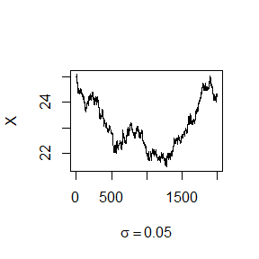

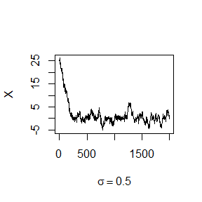

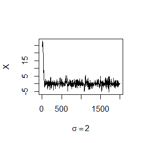

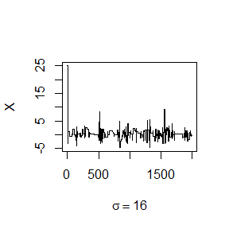

```r
set.seed(0)

lap_f = function(x) 0.5*exp(-abs(x))

rw.Metropolis = function(sigma, x0, N){
  x = numeric(N)
  x[1] = x0
  u = runif(N)
  k = 0
  for (i in 2:N) {
    y = rnorm(1, x[i-1], sigma)
    if (u[i] <= (lap_f(y) / lap_f(x[i-1]))) x[i] = y
    else {
      x[i] = x[i-1]
      k = k+1
    }
  }
  return(list(x = x, k = k))
}

N = 2000
sigma = c(.05, .5, 2, 16)
x0 = 25
rw1 = rw.Metropolis(sigma[1],x0,N)
rw2 = rw.Metropolis(sigma[2],x0,N)
rw3 = rw.Metropolis(sigma[3],x0,N)
rw4 = rw.Metropolis(sigma[4],x0,N)

#plot
# par(mfrow=c(2,2))  #display 4 graphs together
rw = cbind(rw1$x, rw2$x, rw3$x,  rw4$x)
for (j in 1:4) {
  plot(rw[,j], type="l",
       xlab=bquote(sigma == .(round(sigma[j],3))),
       ylab="X", ylim=range(rw[,j]))
}
```

```r
#number of candidate points rejected
Rej = cbind(rw1$k, rw2$k, rw3$k, rw4$k)
Acc = round((N-Rej)/N,4)
rownames(Acc) = "Accept rates"
colnames(Acc) = paste("sigma=",sigma)
knitr::kable(Acc)
```

|  | sigma= 0.05 | sigma= 0.5 | sigma= 2 | sigma= 16 |
| --- | --- | --- | --- | --- |
| Accept rates | 0.977 | 0.8325 | 0.534 | 0.107 |

## Exercises

For Exercise 9.4, use the Gelman-Rubin method to monitor convergence of the chain, and run the chain until it converges approximately to the target distribution according to $\hat{R}< 1.2$.

## Solve.

```r
set.seed(0)
library(GeneralizedHyperbolic)
Gelman.Rubin = function(psi) {
  # psi[i,j] is the statistic psi(X[i,1:j])
  # for chain in i-th row of X
  psi = as.matrix(psi)
  n = ncol(psi)
  k = nrow(psi)
  psi.means = rowMeans(psi)        #row means
  B = n * var(psi.means)           #between variance est.
  psi.w = apply(psi, 1, "var")     #within variances
  W = mean(psi.w)                  #within est.
  v.hat = W*(n-1)/n + (B/n)        #upper variance est.
  r.hat = v.hat / W                #G-R statistic
  return(r.hat)
}

laplace.chain = function(sigma, N, X1) {
  #generates a Metropolis chain for Normal(0,1)
  #with Normal(X[t], sigma) proposal distribution
  #and starting value X1
  x = rep(0, N)
  x[1] = X1
  u = runif(N)
  param = c(0, 1, 1)
  for (i in 2:N) {
    xt = x[i-1]
    y = rnorm(1, xt, sigma) #candidate point
    r1 = dskewlap(y, param = param) * dnorm(xt, y, sigma)
    r2 = dskewlap(xt, param = param) * dnorm(y, xt, sigma)
    r = r1 / r2
    if (u[i] <= r) x[i] = y else
      x[i] = xt
  }
  return(x)
}
sigma =1            #parameter of proposal distribution
k = 4               #number of chains to generate
n = 15000           #length of chains
b = 1000            #burn-in length

#choose overdispersed initial values
x0 = c(-10, -5, 5, 10)

#generate the chains
X = matrix(0, nrow=k, ncol=n)
for (i in 1:k)
  X[i, ] = laplace.chain(sigma, n, x0[i])

#compute diagnostic statistics
psi = t(apply(X, 1, cumsum))
for (i in 1:nrow(psi)){
  psi[i,] = psi[i,] / (1:ncol(psi))
}
print(Gelman.Rubin(psi))
```

```
## [1] 1.0112
```

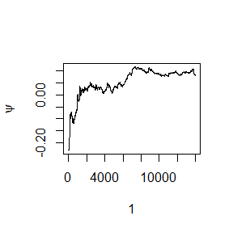

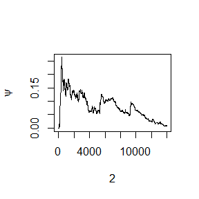

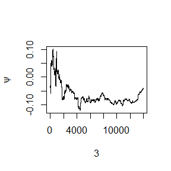

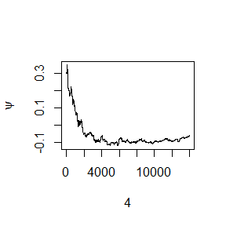

```r
#plot psi for the four chains
#par(mfrow=c(2,2))
for (i in 1:k){
  plot(psi[i, (b+1):n], type="l",xlab=i, ylab=bquote(psi))
}
```

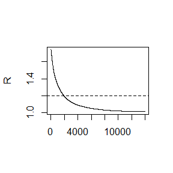

```r
par(mfrow=c(1,1)) #restore default
#plot the sequence of R-hat statistics
rhat = rep(0, n)
for (j in (b+1):n){rhat[j] = Gelman.Rubin(psi[,1:j])}
plot(rhat[(b+1):n], type="l", xlab="", ylab="R")
abline(h=1.2, lty=2)
```

## Exercises 11.4

Find the intersection points $A(k)$ in $(0, \sqrt{k})$ of the curves
$$S_{k-1}(a)=P(t(k-1)>\sqrt{\frac{a^2(k-1)}{k-a^2}}) \\
S_{k}(a)=P(t(k)>\sqrt{\frac{a^2k}{k+1-a^2}})$$
for $k = 4 , 25, 100, 500, 1000$, where $t(k)$ is a Student t random variable with k degrees of freedom.

## Solve.

```r
k=c(4:25,100,500,1000)

S = function(a,k){
  ck = sqrt(a^2*k/(k+1-a^2))
  pt(ck,df=k,lower.tail=FALSE)
}

solve = function(k){
  output = uniroot(function(a){S(a,k)-S(a,k-1)},lower=1,upper=2)
  output$root
}

root = matrix(0,2,length(k))

for (i in 1:length(k)){
  root[2,i]=round(solve(k[i]),4)
}

root[1,] = k
rownames(root) = c('k','A(k)')
root
```

```
##        [,1]   [,2]   [,3]   [,4]   [,5]   [,6]    [,7]    [,8]   [,9]   [,10]
## k    4.0000 5.0000 6.0000 7.0000 8.0000 9.0000 10.0000 11.0000 12.000 13.0000
## A(k) 1.4921 1.5336 1.5627 1.5844 1.6012 1.6145  1.6254  1.6344  1.642  1.6486
##        [,11]   [,12]   [,13]   [,14]   [,15]   [,16]   [,17]   [,18]   [,19]
## k    14.0000 15.0000 16.0000 17.0000 18.0000 19.0000 20.0000 21.0000 22.0000
## A(k)  1.6542  1.6591  1.6635  1.6673  1.6707  1.6738  1.6766  1.6792  1.6815
##        [,20]   [,21]   [,22]    [,23]    [,24]     [,25]
## k    23.0000 24.0000 25.0000 100.0000 500.0000 1000.0000
## A(k)  1.6836  1.6856  1.6874   1.7206   1.7298    1.7309
```

# HW-2020-11-24

## Exercises

A-B-O blood type problem. $n_{A\cdot}=n_{AA}+n_{AO}=444(A-type),n_{B\cdot}=n_{BB}+n_{BO}=132(B-type),n_{OO}=361(O-type),n_{A B}=63(AB-type)$.

Record the values of p and q that maximize the conditional likelihood in each EM steps, calculate the corresponding log-maximum likelihood values (for observed data), are they increasing?

## Solve.

```r
library(nloptr)
# Mle
eval_f0 = function(x,x1,n.A=444,n.B=132,nOO=361,nAB=63) {

  r1 = 1-sum(x1)
  nAA = n.A*x1[1]^2/(x1[1]^2+2*x1[1]*r1)
  nBB = n.B*x1[2]^2/(x1[2]^2+2*x1[2]*r1)
  r = 1-sum(x)
  return(-2*nAA*log(x[1])-2*nBB*log(x[2])-2*nOO*log(r)-
           (n.A-nAA)*log(2*x[1]*r)-(n.B-nBB)*log(2*x[2]*r)-nAB*log(2*x[1]*x[2]))
}


# constraint
eval_g0 = function(x,x1,n.A=444,n.B=132,nOO=361,nAB=63) {
  return(sum(x)-0.999999)
}

opts = list("algorithm"="NLOPT_LN_COBYLA","xtol_rel"=1.0e-8)

mle = NULL
r = matrix(0,1,2)
r = rbind(r,c(0.25,0.25))        # the beginning value of p0 and q0
j = 2
while (sum(abs(r[j,]-r[j-1,]))>1e-8) {
  res = nloptr( x0=c(0.3,0.1),
                eval_f=eval_f0,
                lb = c(0,0), ub = c(1,1),
                eval_g_ineq = eval_g0,
                opts = opts, x1=r[j,],n.A=444,n.B=132,nOO=361,nAB=63 )
  j = j+1
  r = rbind(r,res$solution)
  mle = c(mle,-eval_f0(x=r[j,],x1=r[j-1,]))
}
#the result of EM algorithm
r=cbind(r,mle)
colnames(r)=c("p","q","log_Mle")
r
```

```
##               p         q   log_Mle
##  [1,] 0.0000000 0.0000000 -1467.009
##  [2,] 0.2500000 0.2500000 -1431.343
##  [3,] 0.2979000 0.1107000 -1428.187
##  [4,] 0.2981639 0.1031484 -1427.792
##  [5,] 0.2977599 0.1027347 -1427.729
##  [6,] 0.2976635 0.1027088 -1427.718
##  [7,] 0.2976449 0.1027066 -1427.716
##  [8,] 0.2976414 0.1027063 -1427.716
##  [9,] 0.2976408 0.1027063 -1427.716
## [10,] 0.2976407 0.1027063 -1427.716
## [11,] 0.2976407 0.1027063 -1427.716
## [12,] 0.2976407 0.1027063 -1427.716
## [13,] 0.2976407 0.1027063 -1467.009
## [14,] 0.2976407 0.1027063 -1431.343
```

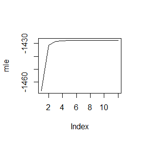

```r
#the log_max likelihood values
plot(mle,type = 'l')
```

## Exercises 3 (page 204)

Use both for loops and lapply() to ﬁt linear models to the mtcars using the formulas stored in this list: formulas <- list( mpg ~ disp, mpg ~ I(1 / disp), mpg ~ disp + wt, mpg ~ I(1 / disp) + wt )

## Solve.

```r
attach(mtcars)

formulas = list(
  mpg ~ disp,
  mpg ~ I(1 / disp),
  mpg ~ disp + wt,
  mpg ~ I(1 / disp) + wt
)
#1 for loops
f1 = vector("list", length(formulas))
for (i in seq_along(formulas)){
  f1[[i]] = lm(formulas[[i]], data = mtcars)
}
f1
```

```
## [[1]]
##
## Call:
## lm(formula = formulas[[i]], data = mtcars)
##
## Coefficients:
## (Intercept)         disp
##    29.59985     -0.04122
##
##
## [[2]]
##
## Call:
## lm(formula = formulas[[i]], data = mtcars)
##
## Coefficients:
## (Intercept)    I(1/disp)
##       10.75      1557.67
##
##
## [[3]]
##
## Call:
## lm(formula = formulas[[i]], data = mtcars)
##
## Coefficients:
## (Intercept)         disp           wt
##    34.96055     -0.01772     -3.35083
##
##
## [[4]]
##
## Call:
## lm(formula = formulas[[i]], data = mtcars)
##
## Coefficients:
## (Intercept)    I(1/disp)           wt
##      19.024     1142.560       -1.798
```

```r
#2 lapply
f2 = lapply(formulas, function(x) lm(formula = x, data = mtcars))
f2
```

```
## [[1]]
##
## Call:
## lm(formula = x, data = mtcars)
##
## Coefficients:
## (Intercept)         disp
##    29.59985     -0.04122
##
##
## [[2]]
##
## Call:
## lm(formula = x, data = mtcars)
##
## Coefficients:
## (Intercept)    I(1/disp)
##       10.75      1557.67
##
##
## [[3]]
##
## Call:
## lm(formula = x, data = mtcars)
##
## Coefficients:
## (Intercept)         disp           wt
##    34.96055     -0.01772     -3.35083
##
##
## [[4]]
##
## Call:
## lm(formula = x, data = mtcars)
##
## Coefficients:
## (Intercept)    I(1/disp)           wt
##      19.024     1142.560       -1.798
```

## Exercises 3 (page 213)

The following code simulates the performance of a t-test for non-normal data. Use sapply() and an anonymous function to extract the p-value from every trial. trials <- replicate( 100, t.test(rpois(10, 10), rpois(7, 10)), simplify = FALSE )

## Solve.

```r
set.seed(0)
trials = replicate(
  100,
  t.test(rpois(10, 10), rpois(7, 10)),
  simplify = FALSE
)
# anonymous function:
sapply(trials, function(x) x[["p.value"]])
```

```
##   [1] 0.027244088 0.970264651 0.841614412 0.843607534 0.059771356 0.722565615
##   [7] 0.683770819 0.039356387 0.571554185 0.289565805 0.611798048 0.203644404
##  [13] 0.054600483 0.904607967 0.911841272 0.351889669 0.353569835 0.272205552
##  [19] 0.757591119 0.791269351 0.114922202 0.993893302 0.296951195 0.320241743
##  [25] 0.762052132 0.972673027 0.868058892 0.319256648 0.005775194 0.145719710
##  [31] 0.747811983 0.870617757 0.366735265 0.611954997 0.807865913 0.097214871
##  [37] 0.021657065 0.132021699 0.867490265 0.814267631 0.979102573 0.823335779
##  [43] 0.342437781 0.284830597 0.945349534 0.626075852 0.330823784 0.775045162
##  [49] 0.753765324 0.974309768 0.878214260 0.579870246 0.236994834 0.254781526
##  [55] 0.912569430 0.456450307 0.971808406 0.349497761 0.317251742 0.501850909
##  [61] 0.982182468 0.674102099 0.172421678 0.056164440 0.439805001 0.239097048
##  [67] 0.272963057 0.613416546 0.908244699 0.030085567 0.768092643 0.271132464
##  [73] 0.786240282 0.597826382 0.288313418 0.387335398 0.879953357 0.598278028
##  [79] 0.782806088 0.957829375 0.248056399 0.080852294 0.142817718 0.050115673
##  [85] 0.347015979 0.532744893 0.841528996 0.808712238 0.502939014 0.384968428
##  [91] 0.858258529 0.418853293 0.671383188 0.581131788 0.076598832 0.885933508
##  [97] 0.905180521 0.006526158 0.068241877 0.502265782
```

```r
## extra challenge:
sapply(trials, "[[" ,3)
```

```
##   [1] 0.027244088 0.970264651 0.841614412 0.843607534 0.059771356 0.722565615
##   [7] 0.683770819 0.039356387 0.571554185 0.289565805 0.611798048 0.203644404
##  [13] 0.054600483 0.904607967 0.911841272 0.351889669 0.353569835 0.272205552
##  [19] 0.757591119 0.791269351 0.114922202 0.993893302 0.296951195 0.320241743
##  [25] 0.762052132 0.972673027 0.868058892 0.319256648 0.005775194 0.145719710
##  [31] 0.747811983 0.870617757 0.366735265 0.611954997 0.807865913 0.097214871
##  [37] 0.021657065 0.132021699 0.867490265 0.814267631 0.979102573 0.823335779
##  [43] 0.342437781 0.284830597 0.945349534 0.626075852 0.330823784 0.775045162
##  [49] 0.753765324 0.974309768 0.878214260 0.579870246 0.236994834 0.254781526
##  [55] 0.912569430 0.456450307 0.971808406 0.349497761 0.317251742 0.501850909
##  [61] 0.982182468 0.674102099 0.172421678 0.056164440 0.439805001 0.239097048
##  [67] 0.272963057 0.613416546 0.908244699 0.030085567 0.768092643 0.271132464
##  [73] 0.786240282 0.597826382 0.288313418 0.387335398 0.879953357 0.598278028
##  [79] 0.782806088 0.957829375 0.248056399 0.080852294 0.142817718 0.050115673
##  [85] 0.347015979 0.532744893 0.841528996 0.808712238 0.502939014 0.384968428
##  [91] 0.858258529 0.418853293 0.671383188 0.581131788 0.076598832 0.885933508
##  [97] 0.905180521 0.006526158 0.068241877 0.502265782
```

## Exercises 6 (page 214)

Implement a combination of Map() and vapply() to create an lapply() variant that iterates in parallel over all of its inputs and stores its outputs in a vector (or a matrix). What argu- ments should the function take?

## Solve.

The function should take arguments: data,funct,output_type

```r
attach(mtcars)
```

```r
lapply1=function(data,funct,output_type){
  new=Map(funct,data)
  vapply(new,function(x) x , output_type)
}

##   Example
lapply1(mtcars,median,double(1))
```

```
##     mpg     cyl    disp      hp    drat      wt    qsec      vs      am    gear
##  19.200   6.000 196.300 123.000   3.695   3.325  17.710   0.000   0.000   4.000
##    carb
##   2.000
```

# HW-2020-12-01

## Exercises

Write an Rcpp function for Exercise 9.4 (page 277, Statistical Computing with R).  
1. Compare the corresponding generated random numbers with those by the R function you wrote before using the function “qqplot”.  
2. Campare the computation time of the two functions with the function “microbenchmark”.  
3. Comments your results.

## Solve.

### Rcpp code

```cpp
#include <cmath>
#include <Rcpp.h>
using namespace Rcpp;

//[[Rcpp::export]]
double f(double x) {
  return exp(-abs(x));
}

//[[Rcpp::export]]
NumericVector rwC_Metropolis (double sigma, double x0, int N) {
  NumericVector x(N);
  x[0] = x0;
  NumericVector u = runif(N);
  for (int i = 1; i < N;i++ ) {
    NumericVector y = rnorm(1, x[i-1], sigma);
    if (u[i] <= (f(y[0]) / f(x[i-1]))){
      x[i] = y[0];
    }
    else {
      x[i] = x[i-1];
    }
  }
  return(x);
}
```

### 1. Compare the corresponding generated random numbers with those by the R function you wrote before using the function “qqplot”.

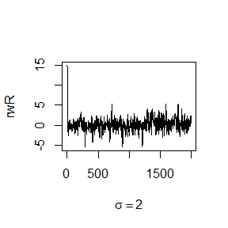

```r
set.seed(0)
library(Rcpp)
library(microbenchmark)

# R
lap_f = function(x) exp(-abs(x))

rwR_Metropolis = function(sigma, x0, N){
  x = numeric(N)
  x[1] = x0
  u = runif(N)
  k = 0

  for (i in 2:N) {
    y = rnorm(1, x[i-1], sigma)
    if (u[i] <= (lap_f(y) / lap_f(x[i-1]))) x[i] = y
    else {
      x[i] = x[i-1]
      k = k+1
      }
    }
    return(list(x = x, k = k))
  }

dir_cpp = 'C:/Users/admin/Desktop/StatComp20068/src/'
sourceCpp(paste0(dir_cpp,"rwC_Metropolis.cpp"))
x0 = 15
N = 2000
sigma = 2
rwR=rwR_Metropolis(sigma,x0,N)
rwC=rwC_Metropolis(sigma,x0,N)

#par(mfrow=c(1,2))
plot(rwR$x,type = "l",xlab =bquote(sigma==2),ylab = "rwR",ylim = range(rwR$x))
```

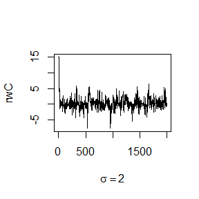

```r
plot(rwC,type = "l",xlab =bquote(sigma==2),ylab = "rwC",ylim = range(rwC))
```

### qqplot

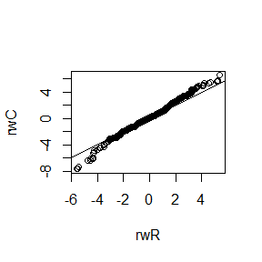

```r
set.seed(0)
rwR = rwR_Metropolis(sigma,x0,N)$x[-(1:100)]
rwC = rwC_Metropolis(sigma,x0,N)[-(1:100)]
qqplot(rwR,rwC)
abline(a=0,b=1,col='black')
```

### 2.Campare the computation time of the two functions with the function “microbenchmark”.

```r
set.seed(0)
(time = microbenchmark(rwR=rwR_Metropolis(sigma,x0,N),rwC=rwC_Metropolis(sigma,x0,N)))
```

```
## Unit: microseconds
##  expr      min       lq      mean   median         uq       max neval
##   rwR 7953.401 8667.352 10841.473 9809.001 11186.2015 22345.201   100
##   rwC  481.301  504.951   586.262  534.201   642.1505  1057.501   100
```

### 3. Comments your results.

According to the calculation results, we find that the running time of cpp is far less than the running time of R, which greatly improves the efficiency of calculation.

Most of the points drawn by qqplot are located near the diagonal, so the random numbers generated by these two functions are similar.